# Risk Factor Analysis

## Outcome Variable

**Outcome Variable:** ever_stunted

## Predictor Variables

**Intervention Variable:** birthwt

**Adjustment Set:**

unadjusted

## Stratifying Variables

The analysis was stratified on these variable(s):

- agecat
- studyid

The following strata were considered:

- agecat: 12 months, studyid: ki0047075b-MAL-ED
- agecat: 12 months, studyid: ki1000108-CMC-V-BCS-2002
- agecat: 12 months, studyid: ki1000108-IRC
- agecat: 12 months, studyid: ki1000109-EE
- agecat: 12 months, studyid: ki1017093b-PROVIDE
- agecat: 12 months, studyid: ki1017093c-NIH-Crypto
- agecat: 12 months, studyid: ki1066203-TanzaniaChild2
- agecat: 12 months, studyid: ki1101329-Keneba
- agecat: 12 months, studyid: ki1126311-ZVITAMBO
- agecat: 12 months, studyid: ki1135781-COHORTS
- agecat: 18 months, studyid: ki0047075b-MAL-ED
- agecat: 18 months, studyid: ki1000108-CMC-V-BCS-2002
- agecat: 18 months, studyid: ki1000108-IRC
- agecat: 18 months, studyid: ki1000109-EE
- agecat: 18 months, studyid: ki1017093b-PROVIDE
- agecat: 18 months, studyid: ki1017093c-NIH-Crypto
- agecat: 18 months, studyid: ki1066203-TanzaniaChild2
- agecat: 18 months, studyid: ki1101329-Keneba
- agecat: 18 months, studyid: ki1126311-ZVITAMBO
- agecat: 18 months, studyid: ki1135781-COHORTS
- agecat: 24 months, studyid: ki0047075b-MAL-ED
- agecat: 24 months, studyid: ki1000108-CMC-V-BCS-2002
- agecat: 24 months, studyid: ki1000108-IRC
- agecat: 24 months, studyid: ki1000109-EE
- agecat: 24 months, studyid: ki1017093b-PROVIDE
- agecat: 24 months, studyid: ki1017093c-NIH-Crypto
- agecat: 24 months, studyid: ki1066203-TanzaniaChild2
- agecat: 24 months, studyid: ki1101329-Keneba
- agecat: 24 months, studyid: ki1126311-ZVITAMBO
- agecat: 24 months, studyid: ki1135781-COHORTS
- agecat: 3 months, studyid: ki0047075b-MAL-ED
- agecat: 3 months, studyid: ki1000108-CMC-V-BCS-2002
- agecat: 3 months, studyid: ki1000108-IRC
- agecat: 3 months, studyid: ki1000109-EE
- agecat: 3 months, studyid: ki1017093b-PROVIDE
- agecat: 3 months, studyid: ki1017093c-NIH-Crypto
- agecat: 3 months, studyid: ki1066203-TanzaniaChild2
- agecat: 3 months, studyid: ki1101329-Keneba
- agecat: 3 months, studyid: ki1126311-ZVITAMBO
- agecat: 3 months, studyid: ki1135781-COHORTS
- agecat: 6 months, studyid: ki0047075b-MAL-ED
- agecat: 6 months, studyid: ki1000108-CMC-V-BCS-2002
- agecat: 6 months, studyid: ki1000108-IRC
- agecat: 6 months, studyid: ki1000109-EE
- agecat: 6 months, studyid: ki1017093b-PROVIDE
- agecat: 6 months, studyid: ki1017093c-NIH-Crypto
- agecat: 6 months, studyid: ki1066203-TanzaniaChild2
- agecat: 6 months, studyid: ki1101329-Keneba
- agecat: 6 months, studyid: ki1126311-ZVITAMBO
- agecat: 6 months, studyid: ki1135781-COHORTS

### Dropped Strata

Some strata were dropped due to rare outcomes:

- agecat: 3 months, studyid: ki1017093b-PROVIDE
- agecat: 3 months, studyid: ki1017093c-NIH-Crypto
- agecat: 6 months, studyid: ki1017093b-PROVIDE
- agecat: 6 months, studyid: ki1017093c-NIH-Crypto
- agecat: 12 months, studyid: ki1017093b-PROVIDE
- agecat: 18 months, studyid: ki1017093b-PROVIDE
- agecat: 24 months, studyid: ki1000108-CMC-V-BCS-2002
- agecat: 24 months, studyid: ki1000109-EE
- agecat: 24 months, studyid: ki1017093b-PROVIDE

## Methods Detail

We’re interested in the causal parameters $E[Y_a]$ for all values of $a \in \mathcal{A}$. These parameters represent the mean outcome if, possibly contrary to fact, we intervened to set all units to have $A=a$. Under the randomization and positivity assumptions, these are identified by the statistical parameters $\psi_a=E_W[E_{Y|A,W}(Y|A=a,W)]$. In addition, we’re interested in the mean of $Y$, $E[Y]$ under no intervention (the observed mean). We will estimate these parameters by using SuperLearner to fit the relevant likelihood factors – $E_{Y|A,W}(Y|A=a,W)$ and $p(A=a|W)$, and then updating our likelihood fit using a joint TMLE.

For unadjusted analyses ($W=\{\}$), initial likelihoods were estimated using Lrnr_glm to estimate the simple $E(Y|A)$ and Lrnr_mean to estimate $p(A)$. For adjusted analyses, a small library containing Lrnr_glmnet, Lrnr_xgboost, and Lrnr_mean was used.

Having estimated these parameters, we will then use the delta method to estimate relative risks and attributable risks relative to a prespecified baseline level of $A$.

# Results Detail

## Results Plots

[figure not shown]

[figure not shown]

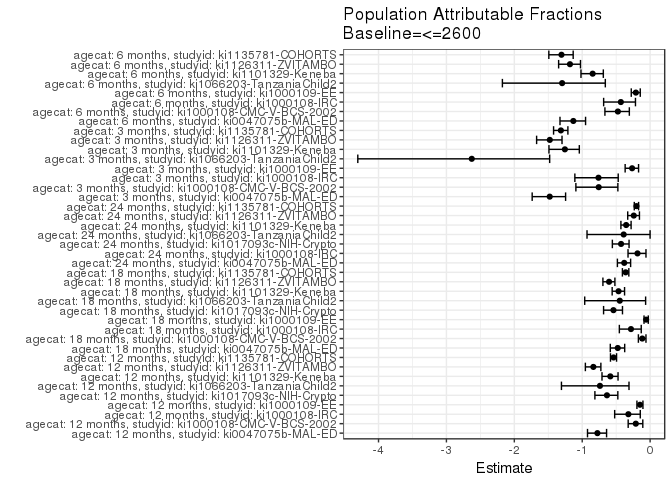

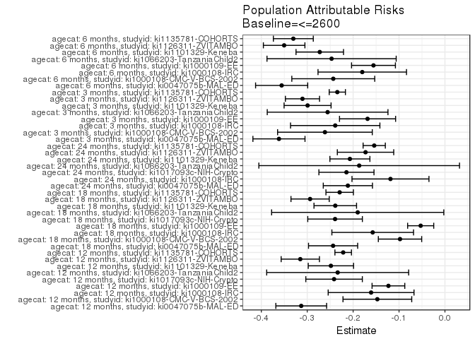

## Data Summary

| agecat | studyid | A | n | nA | nAY0 | nAY1 |
| --- | --- | --- | --- | --- | --- | --- |
| 3 months | ki0047075b-MAL-ED | <=2600 | 1697 | 292 | 115 | 177 |
| 3 months | ki0047075b-MAL-ED | (2600-2970] | 1697 | 376 | 264 | 112 |
| 3 months | ki0047075b-MAL-ED | (2970-3302.75] | 1697 | 548 | 455 | 93 |
| 3 months | ki0047075b-MAL-ED | >3302.75 | 1697 | 481 | 448 | 33 |
| 3 months | ki1000108-CMC-V-BCS-2002 | <=2600 | 362 | 89 | 35 | 54 |
| 3 months | ki1000108-CMC-V-BCS-2002 | (2600-2970] | 362 | 83 | 50 | 33 |
| 3 months | ki1000108-CMC-V-BCS-2002 | (2970-3302.75] | 362 | 126 | 98 | 28 |
| 3 months | ki1000108-CMC-V-BCS-2002 | >3302.75 | 362 | 64 | 54 | 10 |
| 3 months | ki1000108-IRC | <=2600 | 404 | 103 | 46 | 57 |
| 3 months | ki1000108-IRC | (2600-2970] | 404 | 124 | 84 | 40 |
| 3 months | ki1000108-IRC | (2970-3302.75] | 404 | 116 | 93 | 23 |
| 3 months | ki1000108-IRC | >3302.75 | 404 | 61 | 54 | 7 |
| 3 months | ki1000109-EE | <=2600 | 379 | 179 | 35 | 144 |
| 3 months | ki1000109-EE | (2600-2970] | 379 | 96 | 39 | 57 |
| 3 months | ki1000109-EE | (2970-3302.75] | 379 | 70 | 38 | 32 |
| 3 months | ki1000109-EE | >3302.75 | 379 | 34 | 26 | 8 |
| 3 months | ki1017093b-PROVIDE | <=2600 | 175 | 54 | 23 | 31 |
| 3 months | ki1017093b-PROVIDE | (2600-2970] | 175 | 66 | 56 | 10 |
| 3 months | ki1017093b-PROVIDE | (2970-3302.75] | 175 | 44 | 42 | 2 |
| 3 months | ki1017093b-PROVIDE | >3302.75 | 175 | 11 | 10 | 1 |
| 3 months | ki1017093c-NIH-Crypto | <=2600 | 758 | 263 | 170 | 93 |
| 3 months | ki1017093c-NIH-Crypto | (2600-2970] | 758 | 230 | 210 | 20 |
| 3 months | ki1017093c-NIH-Crypto | (2970-3302.75] | 758 | 177 | 171 | 6 |
| 3 months | ki1017093c-NIH-Crypto | >3302.75 | 758 | 88 | 86 | 2 |
| 3 months | ki1066203-TanzaniaChild2 | <=2600 | 596 | 51 | 33 | 18 |
| 3 months | ki1066203-TanzaniaChild2 | (2600-2970] | 596 | 72 | 57 | 15 |
| 3 months | ki1066203-TanzaniaChild2 | (2970-3302.75] | 596 | 233 | 214 | 19 |
| 3 months | ki1066203-TanzaniaChild2 | >3302.75 | 596 | 240 | 234 | 6 |
| 3 months | ki1101329-Keneba | <=2600 | 1917 | 372 | 172 | 200 |
| 3 months | ki1101329-Keneba | (2600-2970] | 1917 | 595 | 446 | 149 |

[output cut: 170 more lines]

## Results Table

### Parameter: TSM

| agecat | studyid | intervention_level | baseline_level | estimate | ci_lower | ci_upper |
| --- | --- | --- | --- | --- | --- | --- |
| 3 months | ki0047075b-MAL-ED | <=2600 | NA | 0.6061644 | 0.5501064 | 0.6622224 |
| 3 months | ki0047075b-MAL-ED | (2600-2970] | NA | 0.2978723 | 0.2516337 | 0.3441110 |
| 3 months | ki0047075b-MAL-ED | (2970-3302.75] | NA | 0.1697080 | 0.1382702 | 0.2011458 |
| 3 months | ki0047075b-MAL-ED | >3302.75 | NA | 0.0686071 | 0.0460099 | 0.0912043 |
| 3 months | ki1000108-CMC-V-BCS-2002 | <=2600 | NA | 0.6067416 | 0.5051180 | 0.7083652 |
| 3 months | ki1000108-CMC-V-BCS-2002 | (2600-2970] | NA | 0.3975904 | 0.2921581 | 0.5030226 |
| 3 months | ki1000108-CMC-V-BCS-2002 | (2970-3302.75] | NA | 0.2222222 | 0.1495305 | 0.2949140 |
| 3 months | ki1000108-CMC-V-BCS-2002 | >3302.75 | NA | 0.1562500 | 0.0671709 | 0.2453291 |
| 3 months | ki1000108-IRC | <=2600 | NA | 0.5533981 | 0.4572708 | 0.6495254 |
| 3 months | ki1000108-IRC | (2600-2970] | NA | 0.3225806 | 0.2402003 | 0.4049609 |
| 3 months | ki1000108-IRC | (2970-3302.75] | NA | 0.1982759 | 0.1256310 | 0.2709207 |
| 3 months | ki1000108-IRC | >3302.75 | NA | 0.1147541 | 0.0346716 | 0.1948366 |
| 3 months | ki1000109-EE | <=2600 | NA | 0.8044693 | 0.7462914 | 0.8626471 |
| 3 months | ki1000109-EE | (2600-2970] | NA | 0.5937500 | 0.4953750 | 0.6921250 |
| 3 months | ki1000109-EE | (2970-3302.75] | NA | 0.4571429 | 0.3402894 | 0.5739963 |
| 3 months | ki1000109-EE | >3302.75 | NA | 0.2352941 | 0.0925247 | 0.3780635 |
| 3 months | ki1066203-TanzaniaChild2 | <=2600 | NA | 0.3529412 | 0.2216756 | 0.4842067 |
| 3 months | ki1066203-TanzaniaChild2 | (2600-2970] | NA | 0.2083333 | 0.1144482 | 0.3022185 |
| 3 months | ki1066203-TanzaniaChild2 | (2970-3302.75] | NA | 0.0815451 | 0.0463759 | 0.1167143 |
| 3 months | ki1066203-TanzaniaChild2 | >3302.75 | NA | 0.0250000 | 0.0052312 | 0.0447688 |
| 3 months | ki1101329-Keneba | <=2600 | NA | 0.5376344 | 0.4869556 | 0.5883132 |
| 3 months | ki1101329-Keneba | (2600-2970] | NA | 0.2504202 | 0.2155987 | 0.2852416 |
| 3 months | ki1101329-Keneba | (2970-3302.75] | NA | 0.1362890 | 0.1090327 | 0.1635453 |
| 3 months | ki1101329-Keneba | >3302.75 | NA | 0.0733138 | 0.0456416 | 0.1009860 |
| 3 months | ki1126311-ZVITAMBO | <=2600 | NA | 0.5204513 | 0.4836729 | 0.5572298 |
| 3 months | ki1126311-ZVITAMBO | (2600-2970] | NA | 0.2190476 | 0.1926736 | 0.2454216 |
| 3 months | ki1126311-ZVITAMBO | (2970-3302.75] | NA | 0.1092437 | 0.0905587 | 0.1279287 |
| 3 months | ki1126311-ZVITAMBO | >3302.75 | NA | 0.0533160 | 0.0374350 | 0.0691970 |
| 3 months | ki1135781-COHORTS | <=2600 | NA | 0.4129305 | 0.3955357 | 0.4303252 |
| 3 months | ki1135781-COHORTS | (2600-2970] | NA | 0.1193548 | 0.1073242 | 0.1313855 |

[output cut: 134 more lines]

### Parameter: E(Y)

| agecat | studyid | intervention_level | baseline_level | estimate | ci_lower | ci_upper |
| --- | --- | --- | --- | --- | --- | --- |
| 3 months | ki0047075b-MAL-ED | NA | NA | 0.2445492 | 0.2358107 | 0.2532877 |
| 3 months | ki1000108-CMC-V-BCS-2002 | NA | NA | 0.3453039 | 0.3277301 | 0.3628776 |
| 3 months | ki1000108-IRC | NA | NA | 0.3143564 | 0.2990828 | 0.3296301 |
| 3 months | ki1000109-EE | NA | NA | 0.6358839 | 0.6172493 | 0.6545186 |
| 3 months | ki1066203-TanzaniaChild2 | NA | NA | 0.0973154 | 0.0895735 | 0.1050573 |
| 3 months | ki1101329-Keneba | NA | NA | 0.2383933 | 0.2312318 | 0.2455549 |
| 3 months | ki1126311-ZVITAMBO | NA | NA | 0.2100744 | 0.2045159 | 0.2156329 |
| 3 months | ki1135781-COHORTS | NA | NA | 0.1784475 | 0.1753544 | 0.1815406 |
| 6 months | ki0047075b-MAL-ED | NA | NA | 0.3146280 | 0.3057610 | 0.3234950 |
| 6 months | ki1000108-CMC-V-BCS-2002 | NA | NA | 0.5122616 | 0.4964094 | 0.5281138 |
| 6 months | ki1000108-IRC | NA | NA | 0.4179104 | 0.4033347 | 0.4324862 |
| 6 months | ki1000109-EE | NA | NA | 0.7426273 | 0.7254452 | 0.7598095 |
| 6 months | ki1066203-TanzaniaChild2 | NA | NA | 0.1905626 | 0.1817270 | 0.1993982 |
| 6 months | ki1101329-Keneba | NA | NA | 0.3221918 | 0.3149430 | 0.3294406 |
| 6 months | ki1126311-ZVITAMBO | NA | NA | 0.2967515 | 0.2888925 | 0.3046105 |
| 6 months | ki1135781-COHORTS | NA | NA | 0.2530287 | 0.2468904 | 0.2591671 |
| 12 months | ki0047075b-MAL-ED | NA | NA | 0.4033943 | 0.3952557 | 0.4115328 |
| 12 months | ki1000108-CMC-V-BCS-2002 | NA | NA | 0.6989247 | 0.6891249 | 0.7087246 |
| 12 months | ki1000108-IRC | NA | NA | 0.5024876 | 0.4874800 | 0.5174951 |
| 12 months | ki1000109-EE | NA | NA | 0.8257373 | 0.8113069 | 0.8401677 |
| 12 months | ki1017093c-NIH-Crypto | NA | NA | 0.3799726 | 0.3663078 | 0.3936374 |
| 12 months | ki1066203-TanzaniaChild2 | NA | NA | 0.3163265 | 0.3065019 | 0.3261512 |
| 12 months | ki1101329-Keneba | NA | NA | 0.4238727 | 0.4171640 | 0.4305813 |
| 12 months | ki1126311-ZVITAMBO | NA | NA | 0.3770169 | 0.3701873 | 0.3838465 |
| 12 months | ki1135781-COHORTS | NA | NA | 0.4118646 | 0.4086304 | 0.4150988 |
| 18 months | ki0047075b-MAL-ED | NA | NA | 0.5112628 | 0.5038450 | 0.5186806 |
| 18 months | ki1000108-CMC-V-BCS-2002 | NA | NA | 0.8471850 | 0.8414847 | 0.8528852 |
| 18 months | ki1000108-IRC | NA | NA | 0.5583127 | 0.5431907 | 0.5734347 |
| 18 months | ki1000109-EE | NA | NA | 0.9118457 | 0.9057557 | 0.9179358 |
| 18 months | ki1017093c-NIH-Crypto | NA | NA | 0.4433566 | 0.4295289 | 0.4571844 |
| 18 months | ki1066203-TanzaniaChild2 | NA | NA | 0.4253521 | 0.4149081 | 0.4357962 |
| 18 months | ki1101329-Keneba | NA | NA | 0.5140187 | 0.5072641 | 0.5207733 |
| 18 months | ki1126311-ZVITAMBO | NA | NA | 0.4859763 | 0.4779508 | 0.4940018 |
| 18 months | ki1135781-COHORTS | NA | NA | 0.6370497 | 0.6325903 | 0.6415092 |
| 24 months | ki0047075b-MAL-ED | NA | NA | 0.5549174 | 0.5478307 | 0.5620042 |
| 24 months | ki1000108-IRC | NA | NA | 0.6386139 | 0.6260059 | 0.6512218 |
| 24 months | ki1017093c-NIH-Crypto | NA | NA | 0.5015773 | 0.4879209 | 0.5152337 |
| 24 months | ki1066203-TanzaniaChild2 | NA | NA | 0.4798387 | 0.4675996 | 0.4920779 |
| 24 months | ki1101329-Keneba | NA | NA | 0.5864578 | 0.5799607 | 0.5929548 |
| 24 months | ki1126311-ZVITAMBO | NA | NA | 0.7191489 | 0.7072215 | 0.7310763 |
| 24 months | ki1135781-COHORTS | NA | NA | 0.7663255 | 0.7628840 | 0.7697670 |

### Parameter: RR

| agecat | studyid | intervention_level | baseline_level | estimate | ci_lower | ci_upper |
| --- | --- | --- | --- | --- | --- | --- |
| 3 months | ki0047075b-MAL-ED | (2600-2970] | <=2600 | 0.4914052 | 0.4101731 | 0.5887248 |
| 3 months | ki0047075b-MAL-ED | (2970-3302.75] | <=2600 | 0.2799703 | 0.2276105 | 0.3443751 |
| 3 months | ki0047075b-MAL-ED | >3302.75 | <=2600 | 0.1131823 | 0.0803901 | 0.1593507 |
| 3 months | ki1000108-CMC-V-BCS-2002 | (2600-2970] | <=2600 | 0.6552878 | 0.4788706 | 0.8966976 |
| 3 months | ki1000108-CMC-V-BCS-2002 | (2970-3302.75] | <=2600 | 0.3662551 | 0.2536184 | 0.5289161 |
| 3 months | ki1000108-CMC-V-BCS-2002 | >3302.75 | <=2600 | 0.2575231 | 0.1421538 | 0.4665242 |
| 3 months | ki1000108-IRC | (2600-2970] | <=2600 | 0.5829089 | 0.4280226 | 0.7938431 |
| 3 months | ki1000108-IRC | (2970-3302.75] | <=2600 | 0.3582880 | 0.2388565 | 0.5374367 |
| 3 months | ki1000108-IRC | >3302.75 | <=2600 | 0.2073627 | 0.1010196 | 0.4256528 |
| 3 months | ki1000109-EE | (2600-2970] | <=2600 | 0.7380642 | 0.6160028 | 0.8843123 |
| 3 months | ki1000109-EE | (2970-3302.75] | <=2600 | 0.5682540 | 0.4356845 | 0.7411614 |
| 3 months | ki1000109-EE | >3302.75 | <=2600 | 0.2924837 | 0.1587522 | 0.5388693 |
| 3 months | ki1066203-TanzaniaChild2 | (2600-2970] | <=2600 | 0.5902778 | 0.3290770 | 1.0588034 |
| 3 months | ki1066203-TanzaniaChild2 | (2970-3302.75] | <=2600 | 0.2310443 | 0.1307267 | 0.4083441 |
| 3 months | ki1066203-TanzaniaChild2 | >3302.75 | <=2600 | 0.0708333 | 0.0295618 | 0.1697247 |
| 3 months | ki1101329-Keneba | (2600-2970] | <=2600 | 0.4657815 | 0.3937538 | 0.5509849 |
| 3 months | ki1101329-Keneba | (2970-3302.75] | <=2600 | 0.2534975 | 0.2032148 | 0.3162221 |
| 3 months | ki1101329-Keneba | >3302.75 | <=2600 | 0.1363636 | 0.0924145 | 0.2012134 |
| 3 months | ki1126311-ZVITAMBO | (2600-2970] | <=2600 | 0.4208801 | 0.3660387 | 0.4839380 |
| 3 months | ki1126311-ZVITAMBO | (2970-3302.75] | <=2600 | 0.2099018 | 0.1744393 | 0.2525737 |
| 3 months | ki1126311-ZVITAMBO | >3302.75 | <=2600 | 0.1024418 | 0.0754267 | 0.1391328 |
| 3 months | ki1135781-COHORTS | (2600-2970] | <=2600 | 0.2890434 | 0.2591304 | 0.3224095 |
| 3 months | ki1135781-COHORTS | (2970-3302.75] | <=2600 | 0.1365881 | 0.1169800 | 0.1594829 |
| 3 months | ki1135781-COHORTS | >3302.75 | <=2600 | 0.0601329 | 0.0428195 | 0.0844467 |
| 6 months | ki0047075b-MAL-ED | (2600-2970] | <=2600 | 0.5346022 | 0.4537479 | 0.6298643 |
| 6 months | ki0047075b-MAL-ED | (2970-3302.75] | <=2600 | 0.3874957 | 0.3274054 | 0.4586146 |
| 6 months | ki0047075b-MAL-ED | >3302.75 | <=2600 | 0.1986779 | 0.1550034 | 0.2546583 |
| 6 months | ki1000108-CMC-V-BCS-2002 | (2600-2970] | <=2600 | 0.7247899 | 0.5773467 | 0.9098873 |
| 6 months | ki1000108-CMC-V-BCS-2002 | (2970-3302.75] | <=2600 | 0.5335157 | 0.4192747 | 0.6788844 |
| 6 months | ki1000108-CMC-V-BCS-2002 | >3302.75 | <=2600 | 0.4549632 | 0.3177931 | 0.6513406 |

[output cut: 93 more lines]

### Parameter: PAR

| agecat | studyid | intervention_level | baseline_level | estimate | ci_lower | ci_upper |
| --- | --- | --- | --- | --- | --- | --- |
| 3 months | ki0047075b-MAL-ED | <=2600 | NA | -0.3616152 | -0.4183502 | -0.3048802 |
| 3 months | ki1000108-CMC-V-BCS-2002 | <=2600 | NA | -0.2614377 | -0.3645696 | -0.1583058 |
| 3 months | ki1000108-IRC | <=2600 | NA | -0.2390416 | -0.3363748 | -0.1417085 |
| 3 months | ki1000109-EE | <=2600 | NA | -0.1685854 | -0.2296747 | -0.1074960 |
| 3 months | ki1066203-TanzaniaChild2 | <=2600 | NA | -0.2556257 | -0.3871194 | -0.1241321 |
| 3 months | ki1101329-Keneba | <=2600 | NA | -0.2992411 | -0.3504234 | -0.2480588 |
| 3 months | ki1126311-ZVITAMBO | <=2600 | NA | -0.3103769 | -0.3475731 | -0.2731808 |
| 3 months | ki1135781-COHORTS | <=2600 | NA | -0.2344830 | -0.2521506 | -0.2168153 |
| 6 months | ki0047075b-MAL-ED | <=2600 | NA | -0.3557424 | -0.4125274 | -0.2989573 |
| 6 months | ki1000108-CMC-V-BCS-2002 | <=2600 | NA | -0.2432940 | -0.3336045 | -0.1529835 |
| 6 months | ki1000108-IRC | <=2600 | NA | -0.1801288 | -0.2765050 | -0.0837525 |
| 6 months | ki1000109-EE | <=2600 | NA | -0.1556777 | -0.2034606 | -0.1078948 |
| 6 months | ki1066203-TanzaniaChild2 | <=2600 | NA | -0.2469374 | -0.3876813 | -0.1061934 |
| 6 months | ki1101329-Keneba | <=2600 | NA | -0.2727091 | -0.3244445 | -0.2209736 |
| 6 months | ki1126311-ZVITAMBO | <=2600 | NA | -0.3503073 | -0.3955560 | -0.3050585 |
| 6 months | ki1135781-COHORTS | <=2600 | NA | -0.3303046 | -0.3737888 | -0.2868204 |
| 12 months | ki0047075b-MAL-ED | <=2600 | NA | -0.3130808 | -0.3683803 | -0.2577814 |
| 12 months | ki1000108-CMC-V-BCS-2002 | <=2600 | NA | -0.1472291 | -0.2221033 | -0.0723549 |
| 12 months | ki1000108-IRC | <=2600 | NA | -0.1608788 | -0.2543662 | -0.0673914 |
| 12 months | ki1000109-EE | <=2600 | NA | -0.1231264 | -0.1587653 | -0.0874874 |
| 12 months | ki1017093c-NIH-Crypto | <=2600 | NA | -0.2415414 | -0.3031193 | -0.1799634 |
| 12 months | ki1066203-TanzaniaChild2 | <=2600 | NA | -0.2336735 | -0.3883155 | -0.0790314 |
| 12 months | ki1101329-Keneba | <=2600 | NA | -0.2484437 | -0.2978092 | -0.1990782 |
| 12 months | ki1126311-ZVITAMBO | <=2600 | NA | -0.3151318 | -0.3568271 | -0.2734366 |
| 12 months | ki1135781-COHORTS | <=2600 | NA | -0.2216802 | -0.2397009 | -0.2036594 |
| 18 months | ki0047075b-MAL-ED | <=2600 | NA | -0.2436779 | -0.2972129 | -0.1901429 |
| 18 months | ki1000108-CMC-V-BCS-2002 | <=2600 | NA | -0.0978700 | -0.1450969 | -0.0506430 |
| 18 months | ki1000108-IRC | <=2600 | NA | -0.1573736 | -0.2463177 | -0.0684295 |
| 18 months | ki1000109-EE | <=2600 | NA | -0.0528602 | -0.0812960 | -0.0244243 |
| 18 months | ki1017093c-NIH-Crypto | <=2600 | NA | -0.2393743 | -0.2988523 | -0.1798962 |
| 18 months | ki1066203-TanzaniaChild2 | <=2600 | NA | -0.1900325 | -0.3775902 | -0.0024748 |
| 18 months | ki1101329-Keneba | <=2600 | NA | -0.2389225 | -0.2852746 | -0.1925704 |
| 18 months | ki1126311-ZVITAMBO | <=2600 | NA | -0.2937706 | -0.3354303 | -0.2521108 |
| 18 months | ki1135781-COHORTS | <=2600 | NA | -0.2293550 | -0.2592505 | -0.1994595 |
| 24 months | ki0047075b-MAL-ED | <=2600 | NA | -0.2114760 | -0.2650569 | -0.1578951 |
| 24 months | ki1000108-IRC | <=2600 | NA | -0.1186677 | -0.2025197 | -0.0348157 |
| 24 months | ki1017093c-NIH-Crypto | <=2600 | NA | -0.2145799 | -0.2745951 | -0.1545647 |
| 24 months | ki1066203-TanzaniaChild2 | <=2600 | NA | -0.1868280 | -0.4053851 | 0.0317292 |
| 24 months | ki1101329-Keneba | <=2600 | NA | -0.2070526 | -0.2506413 | -0.1634639 |
| 24 months | ki1126311-ZVITAMBO | <=2600 | NA | -0.1730079 | -0.2344368 | -0.1115791 |
| 24 months | ki1135781-COHORTS | <=2600 | NA | -0.1540827 | -0.1782976 | -0.1298678 |

### Parameter: PAF

| agecat | studyid | intervention_level | baseline_level | estimate | ci_lower | ci_upper |
| --- | --- | --- | --- | --- | --- | --- |
| 3 months | ki0047075b-MAL-ED | <=2600 | NA | -1.4787011 | -1.7370422 | -1.2447440 |
| 3 months | ki1000108-CMC-V-BCS-2002 | <=2600 | NA | -0.7571236 | -1.0932764 | -0.4749526 |
| 3 months | ki1000108-IRC | <=2600 | NA | -0.7604159 | -1.1083824 | -0.4698776 |
| 3 months | ki1000109-EE | <=2600 | NA | -0.2651197 | -0.3677910 | -0.1701553 |
| 3 months | ki1066203-TanzaniaChild2 | <=2600 | NA | -2.6267748 | -4.3051397 | -1.4793873 |
| 3 months | ki1101329-Keneba | <=2600 | NA | -1.2552411 | -1.4897707 | -1.0428035 |
| 3 months | ki1126311-ZVITAMBO | <=2600 | NA | -1.4774618 | -1.6716395 | -1.2973972 |
| 3 months | ki1135781-COHORTS | <=2600 | NA | -1.3140165 | -1.4218622 | -1.2109732 |
| 6 months | ki0047075b-MAL-ED | <=2600 | NA | -1.1306762 | -1.3273406 | -0.9506303 |
| 6 months | ki1000108-CMC-V-BCS-2002 | <=2600 | NA | -0.4749409 | -0.6657771 | -0.3059674 |
| 6 months | ki1000108-IRC | <=2600 | NA | -0.4310224 | -0.6844896 | -0.2156947 |
| 6 months | ki1000109-EE | <=2600 | NA | -0.2096310 | -0.2777203 | -0.1451702 |
| 6 months | ki1066203-TanzaniaChild2 | <=2600 | NA | -1.2958333 | -2.1755866 | -0.6598038 |
| 6 months | ki1101329-Keneba | <=2600 | NA | -0.8464185 | -1.0182796 | -0.6891917 |
| 6 months | ki1126311-ZVITAMBO | <=2600 | NA | -1.1804734 | -1.3474409 | -1.0253818 |
| 6 months | ki1135781-COHORTS | <=2600 | NA | -1.3054036 | -1.4916342 | -1.1330922 |
| 12 months | ki0047075b-MAL-ED | <=2600 | NA | -0.7761163 | -0.9220497 | -0.6412629 |
| 12 months | ki1000108-CMC-V-BCS-2002 | <=2600 | NA | -0.2106509 | -0.3231272 | -0.1077359 |
| 12 months | ki1000108-IRC | <=2600 | NA | -0.3201647 | -0.5220038 | -0.1450923 |
| 12 months | ki1000109-EE | <=2600 | NA | -0.1491108 | -0.1942545 | -0.1056737 |
| 12 months | ki1017093c-NIH-Crypto | <=2600 | NA | -0.6356811 | -0.8132901 | -0.4754687 |
| 12 months | ki1066203-TanzaniaChild2 | <=2600 | NA | -0.7387097 | -1.3058659 | -0.3110526 |
| 12 months | ki1101329-Keneba | <=2600 | NA | -0.5861281 | -0.7087167 | -0.4723345 |
| 12 months | ki1126311-ZVITAMBO | <=2600 | NA | -0.8358559 | -0.9535283 | -0.7252717 |
| 12 months | ki1135781-COHORTS | <=2600 | NA | -0.5382356 | -0.5835980 | -0.4941725 |
| 18 months | ki0047075b-MAL-ED | <=2600 | NA | -0.4766197 | -0.5864001 | -0.3744362 |
| 18 months | ki1000108-CMC-V-BCS-2002 | <=2600 | NA | -0.1155237 | -0.1727901 | -0.0610536 |
| 18 months | ki1000108-IRC | <=2600 | NA | -0.2818736 | -0.4531750 | -0.1307654 |
| 18 months | ki1000109-EE | <=2600 | NA | -0.0579705 | -0.0897074 | -0.0271579 |
| 18 months | ki1017093c-NIH-Crypto | <=2600 | NA | -0.5399136 | -0.6854203 | -0.4069688 |
| 18 months | ki1066203-TanzaniaChild2 | <=2600 | NA | -0.4467652 | -0.9633016 | -0.0661273 |
| 18 months | ki1101329-Keneba | <=2600 | NA | -0.4648128 | -0.5589823 | -0.3763316 |
| 18 months | ki1126311-ZVITAMBO | <=2600 | NA | -0.6044957 | -0.6951572 | -0.5186831 |
| 18 months | ki1135781-COHORTS | <=2600 | NA | -0.3600268 | -0.4082310 | -0.3134726 |
| 24 months | ki0047075b-MAL-ED | <=2600 | NA | -0.3810945 | -0.4819252 | -0.2871244 |
| 24 months | ki1000108-IRC | <=2600 | NA | -0.1858207 | -0.3253413 | -0.0609877 |
| 24 months | ki1017093c-NIH-Crypto | <=2600 | NA | -0.4278103 | -0.5560766 | -0.3101169 |
| 24 months | ki1066203-TanzaniaChild2 | <=2600 | NA | -0.3893557 | -0.9292932 | -0.0005267 |
| 24 months | ki1101329-Keneba | <=2600 | NA | -0.3530562 | -0.4301825 | -0.2800892 |
| 24 months | ki1126311-ZVITAMBO | <=2600 | NA | -0.2405732 | -0.3299268 | -0.1572229 |
| 24 months | ki1135781-COHORTS | <=2600 | NA | -0.2010669 | -0.2332296 | -0.1697430 |